# Visualisation avec ggplot

## Exercices

Reproduire ce graphique (Les données Iris sont déjà chargées)

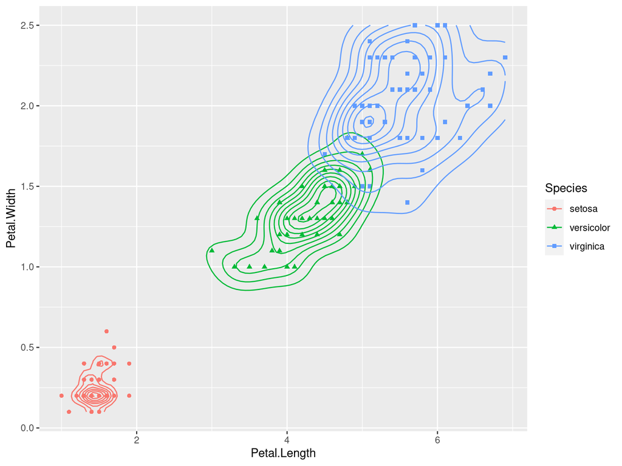

## Exercices

Reproduire ce graphique (Les données mtcars sont déjà chargées) ! modifier le theme du graphique ?theme

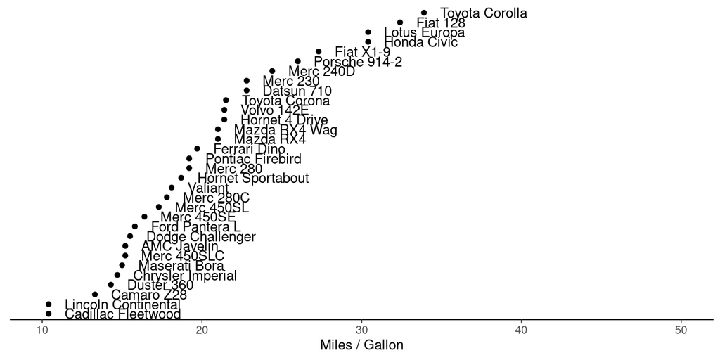

## Exercices

Reproduire ce graphique

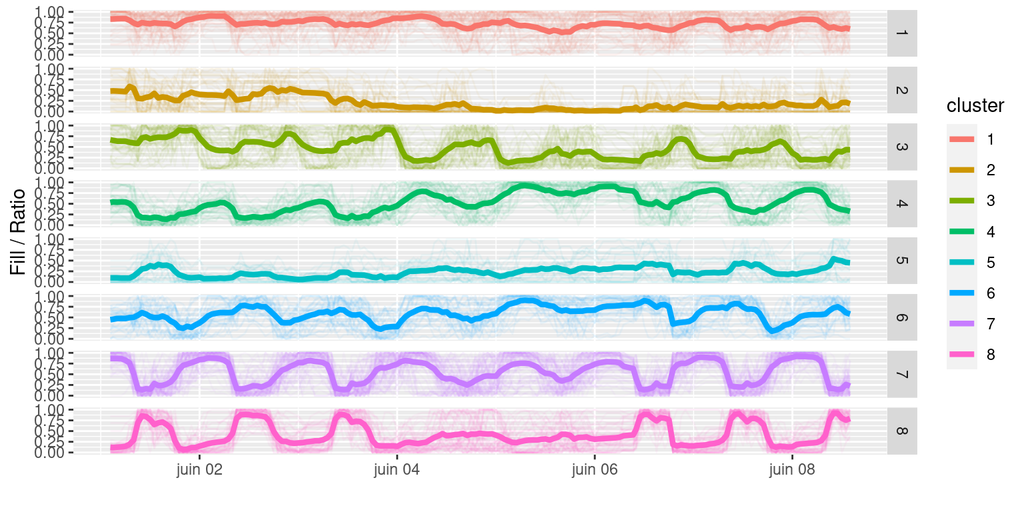

## Exercices

Reproduire ce graphique Informations supplémentaires :

- Données Vélib de New York
- Calculer le taux de remplissage / max(velos disponnibles)
- passer en format large
- k-means en 8 classes Matrixe X (lignes = stations, colonnes = pas de temps)
- facet + courbes moyennes + transparence (alpha)

## Sources

- https://www.r-graph-gallery.com/index.html
- http://www.cis.umassd.edu/~dkoop/cis467
- https://www.namwkim.org/datavis
- https://courses.cs.washington.edu/courses/cse512
- https://serialmentor.com/dataviz/
- http://socviz.co/gettingstarted.html